# data wrangling using tidyverse and dplyr

# 6.12 arrange() orders columns

This is ordered alphabetically, which is cool. But let’s say we wanted to order it in ascending order for year. The dplyr function is arrange().

```r
gapminder %>%
  group_by(continent, year) %>%
  summarize(cont_pop = sum(pop)) %>%
  arrange(year)
```

```
## # A tibble: 60 x 3
## # Groups:   continent [5]
##    continent  year    cont_pop
##    <chr>     <dbl>       <dbl>
##  1 Africa     1952  237640501
##  2 Americas   1952  345152446
##  3 Asia       1952 1395357352.
##  4 Europe     1952  418120846
##  5 Oceania    1952   10686006
##  6 Africa     1957  264837738
##  7 Americas   1957  386953916
##  8 Asia       1957 1562780599
##  9 Europe     1957  437890351
## 10 Oceania    1957   11941976
## # ... with 50 more rows
```

6.12.1 Your turn

```
What is the maximum GDP per continent across all years?
```

6.12.1.1 Answer

```r
gapminder %>%
  mutate(gdp = pop * gdpPercap) %>%
  group_by(continent) %>%
  mutate(max_gdp = max(gdp)) %>%
  filter(gdp == max_gdp)
```

```
## # A tibble: 5 x 8
## # Groups:   continent [5]
##   country        year        pop continent lifeExp gdpPercap     gdp max_gdp
##   <chr>         <dbl>      <dbl> <chr>       <dbl>     <dbl>   <dbl>   <dbl>
## 1 Australia      2007   20434176 Oceania      81.2    34435. 7.04e11 7.04e11
## 2 China          2007 1318683096 Asia         73.0     4959. 6.54e12 6.54e12
## 3 Egypt          2007   80264543 Africa       71.3     5581. 4.48e11 4.48e11
## 4 Germany        2007   82400996 Europe       79.4    32170. 2.65e12 2.65e12
## 5 United States  2007  301139947 Americas     78.2    42952. 1.29e13 1.29e13
```

6.12.2 Your turn

1. arrange your data frame in descending order (opposite of what we’ve done). Expect that this is possible: ?arrange
2. save your data frame as a variable
3. find the maximum life expectancy for countries in Asia. What is the earliest year you encounter? The latest? Hint: you can use or base::max and dplyr::arrange()…
4. Knit your RMarkdown file, and sync it to GitHub (pull, stage, commit, push)

6.12.2.1 Answer

```r
asia_life_exp <- gapminder %>%
  filter(continent == 'Asia') %>%
  group_by(country) %>%
  filter(lifeExp == max(lifeExp)) %>%
  arrange(year) ; asia_life_exp
```

```
## # A tibble: 33 x 6
## # Groups:   country [33]
##    country          year        pop continent lifeExp gdpPercap
##    <chr>           <dbl>      <dbl> <chr>       <dbl>     <dbl>
##  1 Iraq             1987   16543189 Asia         65.0    11644.
##  2 Korea Dem. Rep.  1987   19067554 Asia         70.6     4106.
##  3 Afghanistan      2007   31889923 Asia         43.8      975.
##  4 Bahrain          2007     708573 Asia         75.6    29796.
##  5 Bangladesh       2007  150448339 Asia         64.1     1391.
##  6 Cambodia         2007   14131858 Asia         59.7     1714.
##  7 China            2007 1318683096 Asia         73.0     4959.
##  8 Hong Kong China  2007    6980412 Asia         82.2    39725.
##  9 India            2007 1110396331 Asia         64.7     2452.
## 10 Indonesia        2007  223547000 Asia         70.6     3541.
## # ... with 23 more rows
```

# my own version 1

```r
gapminder %>% filter (continent == "Asia") %>% select (lifeExp, country, continent, year) %>% group_by(country) %>% filter (lifeExp == max(lifeExp)) %>% arrange (lifeExp)
```

```
## # A tibble: 33 x 4
## # Groups:   country [33]
##    lifeExp country     continent  year
##      <dbl> <chr>       <chr>     <dbl>
##  1    43.8 Afghanistan Asia       2007
##  2    59.7 Cambodia    Asia       2007
##  3    62.1 Myanmar     Asia       2007
##  4    62.7 Yemen Rep.  Asia       2007
##  5    63.8 Nepal       Asia       2007
##  6    64.1 Bangladesh  Asia       2007
##  7    64.7 India       Asia       2007
##  8    65.0 Iraq        Asia       1987
##  9    65.5 Pakistan    Asia       2007
## 10    66.8 Mongolia    Asia       2007
## # ... with 23 more rows
```

# my own version 2

```r
gapminder %>% filter (continent == "Asia") %>% select (lifeExp, country, continent, year) %>% group_by(country) %>% filter (lifeExp == max(lifeExp)) %>% arrange (desc(lifeExp))
```

```
## # A tibble: 33 x 4
## # Groups:   country [33]
##    lifeExp country         continent  year
##      <dbl> <chr>           <chr>     <dbl>
##  1    82.6 Japan           Asia       2007
##  2    82.2 Hong Kong China Asia       2007
##  3    80.7 Israel          Asia       2007
##  4    80.0 Singapore       Asia       2007
##  5    78.6 Korea Rep.      Asia       2007
##  6    78.4 Taiwan          Asia       2007
##  7    77.6 Kuwait          Asia       2007
##  8    75.6 Oman            Asia       2007
##  9    75.6 Bahrain         Asia       2007
## 10    74.2 Vietnam         Asia       2007
## # ... with 23 more rows
```

# my own exercise 1

```r
gapminder %>% filter (country == "Indonesia") %>% select(country, year, gdpPercap, pop, lifeExp)
```

```
## # A tibble: 12 x 5
##    country    year gdpPercap       pop lifeExp
##    <chr>     <dbl>     <dbl>     <dbl>   <dbl>
##  1 Indonesia  1952      750.  82052000    37.5
##  2 Indonesia  1957      859.  90124000    39.9
##  3 Indonesia  1962      849.  99028000    42.5
##  4 Indonesia  1967      762. 109343000    46.0
##  5 Indonesia  1972     1111. 121282000    49.2
##  6 Indonesia  1977     1383. 136725000    52.7
##  7 Indonesia  1982     1517. 153343000    56.2
##  8 Indonesia  1987     1748. 169276000    60.1
##  9 Indonesia  1992     2383. 184816000    62.7
## 10 Indonesia  1997     3119. 199278000    66.0
## 11 Indonesia  2002     2874. 211060000    68.6
## 12 Indonesia  2007     3541. 223547000    70.6
```

# my own exercise 2

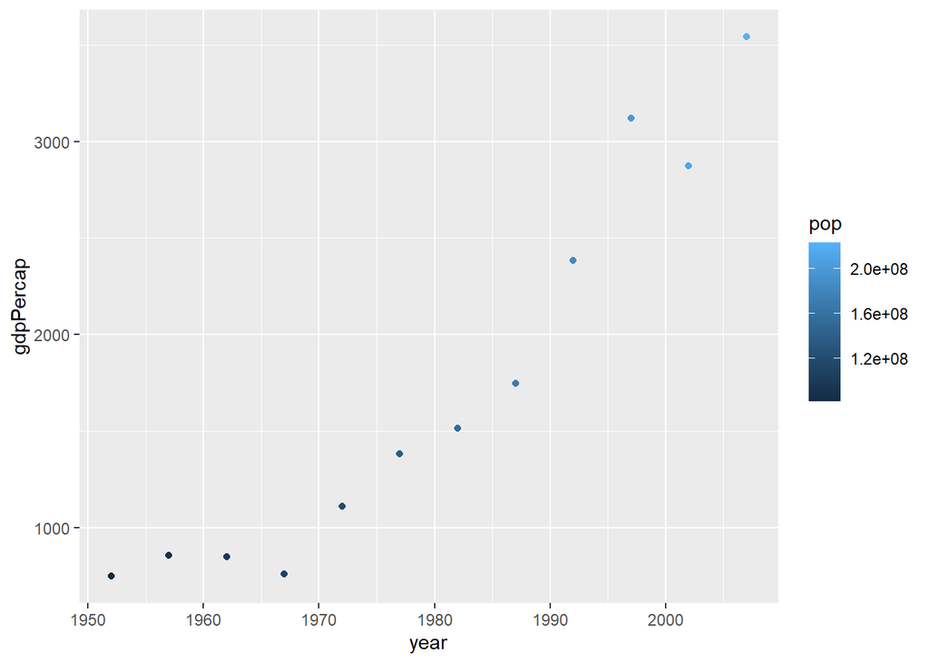

```r
ina <- gapminder %>% filter (country == "Indonesia") %>% select(country, year, gdpPercap, pop, lifeExp) ; ggplot(data = ina) +
    geom_point(aes(x = year, y = gdpPercap, color = pop))
```

# my own exercise 3

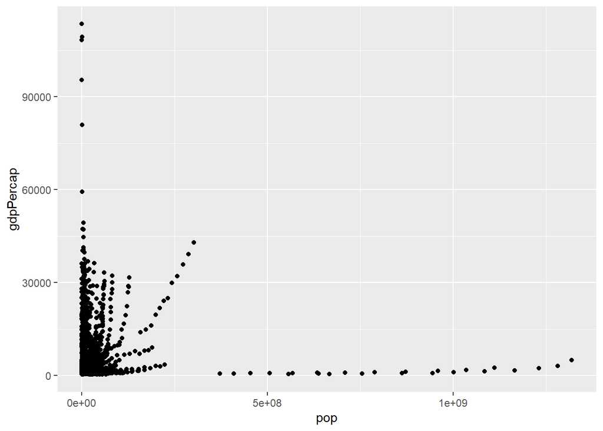

```r
ggplot(data = gapminder) +
    geom_point(aes(x = pop, y = gdpPercap))
```

# 6.13 All together now

```r
gap_max_gdp <- gapminder %>%
  select(-continent, -lifeExp) %>% # or select(country, year, pop, gdpPercap)
  group_by(country) %>%
  mutate(gdp = pop * gdpPercap) %>%
  summarize(max_gdp = max(gdp)) ; gap_max_gdp
```

```
## # A tibble: 142 x 2
##    country           max_gdp
##    <chr>               <dbl>
##  1 Afghanistan  31079291949.
##  2 Albania      21376411360.
##  3 Algeria     207444851958.
##  4 Angola       59583895818.
##  5 Argentina   515033625357.
##  6 Australia   703658358894.
##  7 Austria     296229400691.
##  8 Bahrain      21112675360.
##  9 Bangladesh  209311822134.
## 10 Belgium     350141166520.
## # ... with 132 more rows
```

# my own version 1

```r
gap_max_gdp <- gapminder %>%
  group_by(country) %>%
  mutate(gdp = pop * gdpPercap) %>%
  summarize(max_gdp = max(gdp)) ; gap_max_gdp
```

```
## # A tibble: 142 x 2
##    country           max_gdp
##    <chr>               <dbl>
##  1 Afghanistan  31079291949.
##  2 Albania      21376411360.
##  3 Algeria     207444851958.
##  4 Angola       59583895818.
##  5 Argentina   515033625357.
##  6 Australia   703658358894.
##  7 Austria     296229400691.
##  8 Bahrain      21112675360.
##  9 Bangladesh  209311822134.
## 10 Belgium     350141166520.
## # ... with 132 more rows
```

# my own version 2

```r
gap_max_gdp_cont <- gapminder %>%
  group_by(continent, country, year) %>%
  mutate(gdp_cont = pop * gdpPercap) %>%
  summarize(max_gdp_cont = max(gdp_cont)) %>% arrange (desc(max_gdp_cont)); gap_max_gdp_cont
```

```
## # A tibble: 1,704 x 4
## # Groups:   continent, country [142]
##    continent country        year max_gdp_cont
##    <chr>     <chr>         <dbl>        <dbl>
##  1 Americas  United States  2007      1.29e13
##  2 Americas  United States  2002      1.12e13
##  3 Americas  United States  1997      9.76e12
##  4 Americas  United States  1992      8.22e12
##  5 Americas  United States  1987      7.26e12
##  6 Asia      China          2007      6.54e12
##  7 Americas  United States  1982      5.81e12
##  8 Americas  United States  1977      5.30e12
##  9 Americas  United States  1972      4.58e12
## 10 Asia      Japan          2007      4.04e12
## # ... with 1,694 more rows
```

# my own version 3

```r
gap_max_gdp_cont <- gapminder %>%
  group_by(continent) %>%
  mutate(gdp_cont = pop * gdpPercap) %>%
  summarize(max_gdp_cont = max(gdp_cont)) %>% arrange (desc(max_gdp_cont)); gap_max_gdp_cont
```

```
## # A tibble: 5 x 2
##   continent max_gdp_cont
##   <chr>            <dbl>
## 1 Americas       1.29e13
## 2 Asia           6.54e12
## 3 Europe         2.65e12
## 4 Oceania        7.04e11
## 5 Africa         4.48e11
```

## read in the data. (same URL as yesterday, with co2.csv instead of gapminder.csv)

```r
co2 <- read_csv("https://raw.githubusercontent.com/OHI-Science/data-science-training/master/data/co2.csv")
## explore
co2 %>% head()
```

```
## # A tibble: 6 x 2
##   country        co2_2007
##   <chr>             <dbl>
## 1 Afghanistan      2938.
## 2 Albania          4218.
## 3 Algeria        105838.
## 4 American Samoa     18.4
## 5 Angola          17405.
## 6 Anguilla           12.4
```

```r
co2 %>% dim() # 12
```

```
## [1] 12  2
```

```r
## create new variable that is only 2007 data
gap_2007 <- gapminder %>%
  filter(year == 2007)
gap_2007 %>% dim() # 142
```

```
## [1] 142   6
```

```r
## left_join gap_2007 to co2
lj <- left_join(gap_2007, co2, by = "country")
```

```r
## explore
lj %>% dim() #142
```

```
## [1] 142   7
```

```r
lj %>% summary() # lots of NAs in the co2_2017 columm
```

```
##    country               year           pop             continent
##  Length:142         Min.   :2007   Min.   :1.996e+05   Length:142
##  Class :character   1st Qu.:2007   1st Qu.:4.508e+06   Class :character
##  Mode  :character   Median :2007   Median :1.052e+07   Mode  :character
##                     Mean   :2007   Mean   :4.402e+07
##                     3rd Qu.:2007   3rd Qu.:3.121e+07
##                     Max.   :2007   Max.   :1.319e+09
##
##     lifeExp        gdpPercap          co2_2007
##  Min.   :39.61   Min.   :  277.6   Min.   :  2938
##  1st Qu.:57.16   1st Qu.: 1624.8   1st Qu.: 10811
##  Median :71.94   Median : 6124.4   Median : 75961
##  Mean   :67.01   Mean   :11680.1   Mean   :115407
##  3rd Qu.:76.41   3rd Qu.:18008.8   3rd Qu.:140686
##  Max.   :82.60   Max.   :49357.2   Max.   :425957
##                                    NA's   :135
```

```r
lj %>% View()
```

```r
## right_join gap_2007 and co2
rj <- right_join(gap_2007, co2, by = "country")
```

```r
## explore
rj %>% dim() # 12
```

```
## [1] 12  7
```

```r
rj %>% summary()
```

```
##    country               year           pop            continent
##  Length:12          Min.   :2007   Min.   : 3600523   Length:12
##  Class :character   1st Qu.:2007   1st Qu.:10310130   Class :character
##  Mode  :character   Median :2007   Median :20434176   Mode  :character
##                     Mean   :2007   Mean   :21454289
##                     3rd Qu.:2007   3rd Qu.:32611570
##                     Max.   :2007   Max.   :40301927
##                     NA's   :5      NA's   :5
##     lifeExp        gdpPercap          co2_2007
##  Min.   :42.73   Min.   :  974.6   Min.   :    12.4
##  1st Qu.:58.06   1st Qu.: 5367.1   1st Qu.:  2274.0
##  Median :75.32   Median : 6223.4   Median : 11370.6
##  Mean   :67.38   Mean   :14467.6   Mean   : 70127.8
##  3rd Qu.:78.13   3rd Qu.:23607.4   3rd Qu.: 83430.6
##  Max.   :81.23   Max.   :36126.5   Max.   :425956.6
##  NA's   :5       NA's   :5
```

```r
rj %>% View()
```